# Case Study: Chi-Squared Test of Independence with Banking Data

## Introduction

This study examines the relationship between a client’s job type and possession of a housing loan using a chi-squared test of independence.

**Data Source**: [Bank Market Data](https://ljkelly3141.github.io/ABE-Book/data/bank-full.csv) provided by S. Moro, P. Cortez, and P. Rita (2014)[^1].

**Objective**: Investigate if the `job` type of a client informs us about their likelihood of having a housing loan.

**Variables of Interest**: - `job`: Type of job. - `housing`: Possession of housing loan (yes/no).

1. **Load the Data & Visualize with Mosaic Plot**
   - Use the provided link to download and load the data.
   - Examine the distribution of the `job` and `housing` variables.

```r
# Load Packages
pacman::p_load("tidyverse","vcd")
# Loading the dataset
bank <- read.csv("https://ljkelly3141.github.io/ABE-Book/data/bank-full.csv", sep = ";")
# Distribution check
table(bank$job, bank$housing) %>% knitr::kable()
```

|  | no | yes |
| --- | --- | --- |
| admin. | 1989 | 3182 |
| blue-collar | 2684 | 7048 |
| entrepreneur | 618 | 869 |
| housemaid | 842 | 398 |
| management | 4780 | 4678 |
| retired | 1773 | 491 |
| self-employed | 814 | 765 |
| services | 1388 | 2766 |
| student | 689 | 249 |
| technician | 3482 | 4115 |
| unemployed | 760 | 543 |
| unknown | 262 | 26 |

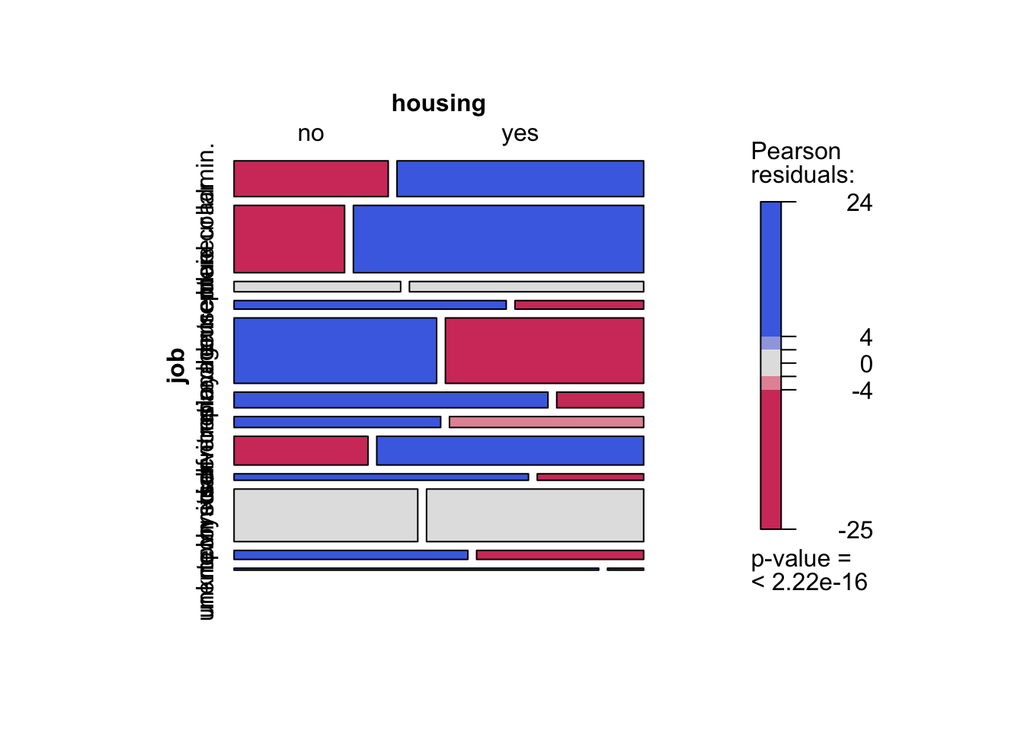

```r
# Using vcd package for mosaic plot
mosaic(~ job + housing, data = bank, shade=TRUE, legend=TRUE)
```

2. **Formulate a Hypothesis**
   - **Null hypothesis** ($H_0$): `job` and `housing` are independent.
   - **Alternate hypothesis** ($H_a$): `job` and `housing` are dependent.
3. **Conduct the Chi-Squared Test of Independence**
   - Use the `table` function to form a cross tabulation of `job` and `housing`.

```r
cross.tab <- table(bank$job, bank$housing)
cross.tab
```

```
##
##                   no  yes
##   admin.        1989 3182
##   blue-collar   2684 7048
##   entrepreneur   618  869
##   housemaid      842  398
##   management    4780 4678
##   retired       1773  491
##   self-employed  814  765
##   services      1388 2766
##   student        689  249
##   technician    3482 4115
##   unemployed     760  543
##   unknown        262   26
```

- Implement the chi-squared test using `chisq.test()` in R.

```r
chisq.stat <- chisq.test(cross.tab)
chisq.stat
```

```
##
##  Pearson's Chi-squared test
##
## data:  cross.tab
## X-squared = 3588.7, df = 11, p-value < 2.2e-16
```

4. **Interpret the Result**
   - If the p-value < $alpha$, reject $H_0$.
   - In this study, due to a very small p-value, $H_0$ is rejected.
   - **Conclusion**: `job` and `housing` variables are dependent.

#### **Final Thoughts**

- The findings suggest certain job categories might be more or less likely to have housing loans.
- Such insights can be valuable for targeted marketing strategies.

## References

[^1]: Moro, S., Cortez, P., & Rita, P. (2014). A Data-Driven Approach to Predict the Success of Bank Telemarketing. Decision Support Systems, Elsevier, 62:22-31. Retrieved from https://archive.ics.uci.edu/ml/datasets/bank+marketing